# Assignment9

assignment for political and social network analysis

Zoe Bean

## The Network

This is an edgelist dataset. It has 298 vertices and 9131 edges, it is not directed or bipartite, and it is weighted. The vertices are the people, with attributes regarding the time and location of their appearances, as well as the point of view the story is in for these appearances.

The dataset is the Game of Thrones Interactions dataset, with characters as nodes, and instances of characters being mentioned in the same vicinity are the edges.

```r
library(tidyverse)
library(GGally)

source("./Import Scripts/Game of Thrones Interactions.R")
```

Here are the network and subnetwork plots that I have managed to create with this data so far:

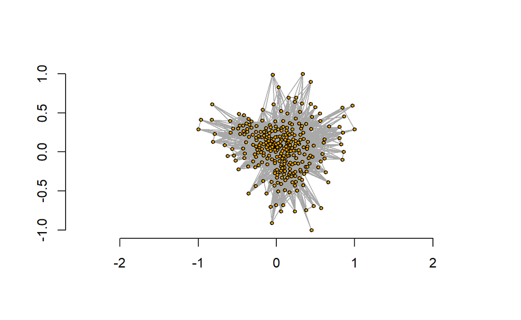

```r
V(network_igraph)$size<-5
V(network_igraph)$label.cex = 1/2
plot(network_igraph, layout_with_lgl(network_igraph), vertex.label=NA)
```

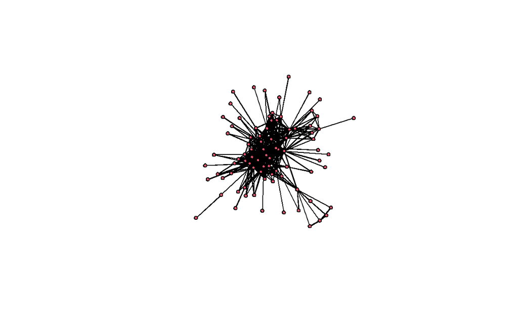

```r
#a subset of the data with a lot of weight on the edges- meaning more interactions between the characters
#weight chosen by rerunning until the plot is somewhat readable
sub_stat<-get.inducedSubgraph(network_statnet,eid=which(network_statnet%e%'weight'>10))
plot(sub_stat)
```

[figure not shown]

```r
#create the same igrpah subset
sub_igraph <- subgraph.edges(network_igraph, E(network_igraph)[E(network_igraph)$weight>10], del=F)
sub_igraph <- delete_vertices(sub_igraph, degree(sub_igraph, mode = "in")==0)

#format igrpah subset to be more readable
V(sub_igraph)$size<-5
V(sub_igraph)$label.cex = 1/2
#plot igrpah
plot(sub_igraph, layout=layout_nicely)
```

## CUG tests

Hypothesis A: The number of edges, and therefore the network density, are not randomly generated.

Hypothesis B: The size of the network is also not randomly generated

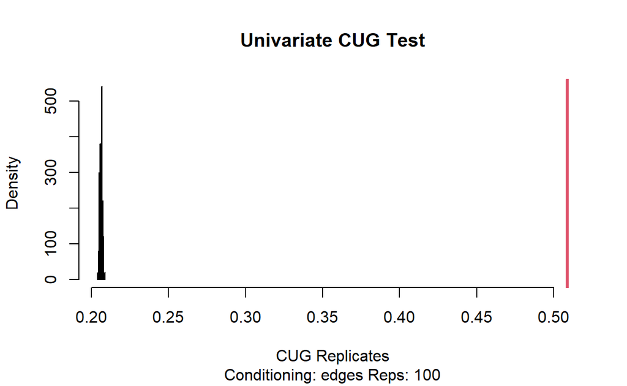

```r
cug.t<-function(cug.object){
  (cug.object$obs.stat-mean(cug.object$rep.stat))/sd(cug.object$rep.stat)
}

edge.cug<-cug.test(chapNet,FUN=gtrans,mode="graph",cmode="edges", reps=100)
plot(edge.cug)
```

```r
cug.t(edge.cug)
```

```
[1] 361.8915
```

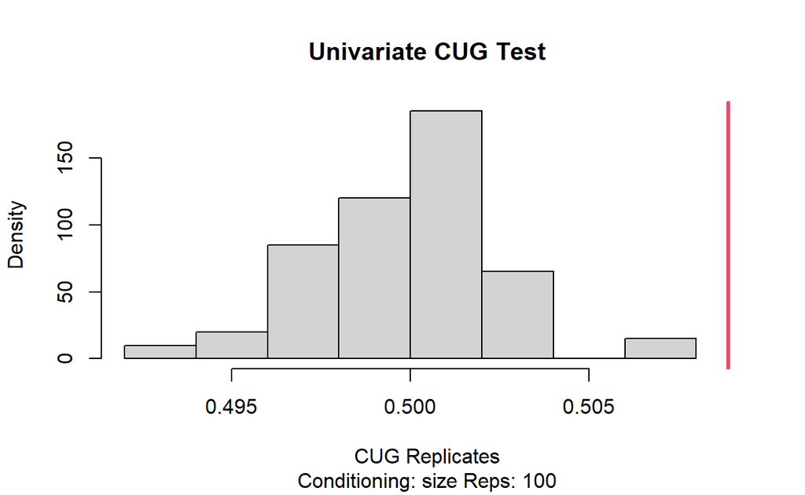

```r
size.cug<-cug.test(chapNet,FUN=gtrans,mode="graph",cmode="size", reps=100)
plot(size.cug)
```

```r
cug.t(size.cug)
```

```
[1] 3.537913
```

This shows that both size and edges are not randomly generated. However, the edges appear to be furthest from the generated networks, likely indicating that all of these connections have been carefully cultivated by the author, especially for a network this size.